# EE550HW2

Erhan Can Ozcan

3/19/2019

## Perceptron Model

50A and 50B instances are generated in 3D as instructed in the lecture. Data is sampled from Chisquare distribution with degree of freedom = 4.

20% of the data is separated as test set by ensuring that the class ratios are kept same. Rest of the data is utilized to train the model. In each iteration, one instance from training set is utilized to update the randomly initialized weight vector.

While training the model, learning rate(step length) is set to 0.001, and sign function is utilized as an activation function.

Since the sampled data is linearly seperable, convergence is expected to be achieved. The convergence can be seen from the **Cumulative Error on Training Set** plot. By changing the initial values of weights and theta, I observed how the number of iterations changes.

**Before training;**

**After training;**

Estimated w vector = [0.0787 0.0725 0.0787]

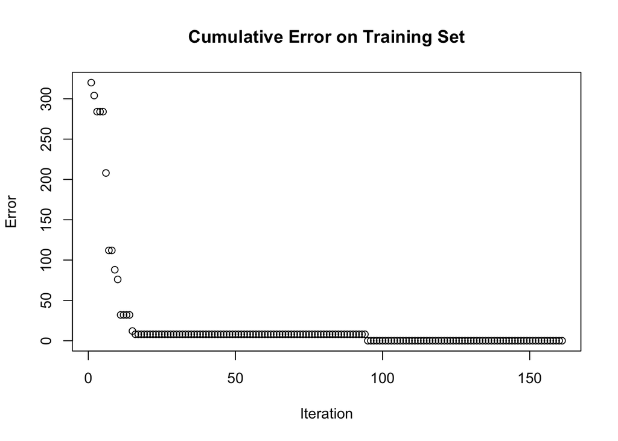

Decision Boundary and the plot of Training Data can be seen from the plot below.

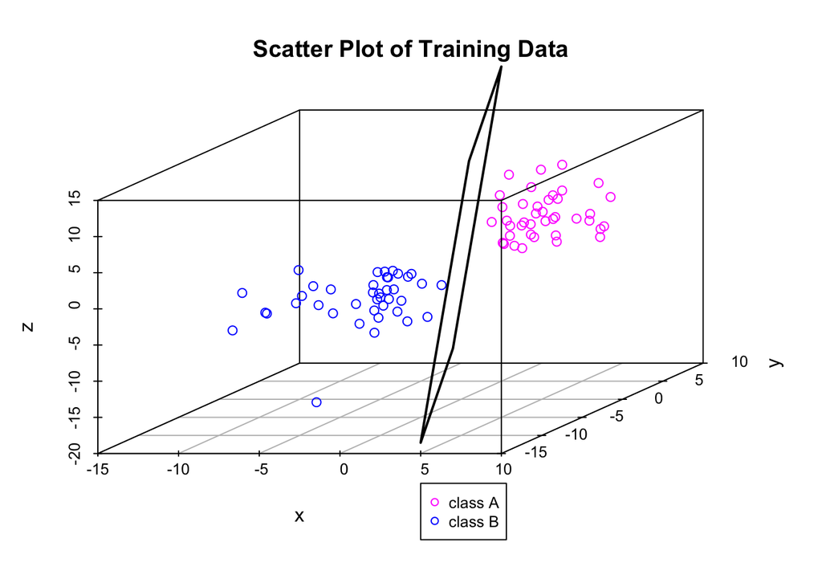

Decision Boundary and the plot of whole Test Data can be seen from the plot below.

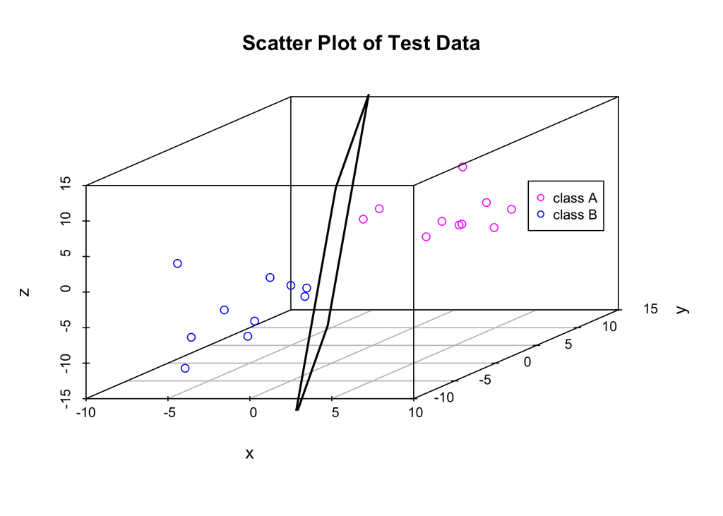

From the plot, we can conclude that the decision boundary can classify the test instances correctly. Still, the learnt weights and theta are used to predict the class of instances. Following table shows all the instances. We can see that all of the test instances are classified correctly.

| x | y | z | actual_class | predicted_class |
| --- | --- | --- | --- | --- |
| 4.5578126 | 4.3344086 | 2.7825198 | 1 | 1 |
| 7.1415127 | 7.6637871 | 2.8225106 | 1 | 1 |
| -0.9009181 | -1.2568319 | -3.7980287 | -1 | -1 |
| -0.5824247 | -2.1205046 | -4.5524773 | -1 | -1 |
| 4.7054930 | 2.1149700 | 1.7247155 | 1 | 1 |
| -1.4753181 | -2.0487374 | -3.0359845 | -1 | -1 |
| -6.2880041 | -5.3274763 | -13.0614473 | -1 | -1 |
| -8.9886931 | -0.8648213 | -0.5414651 | -1 | -1 |
| 4.1016237 | 10.6819107 | 2.2582789 | 1 | 1 |
| -3.3429523 | -3.5690113 | -9.4401404 | -1 | -1 |
| -3.5723847 | -5.9749202 | -4.5303215 | -1 | -1 |
| 5.1606098 | 5.2208079 | 1.8175767 | 1 | 1 |
| 5.3487750 | 5.1894561 | 1.9720173 | 1 | 1 |
| -1.9181686 | -3.6979615 | -1.1044793 | -1 | -1 |
| 5.6732854 | 4.6312511 | 10.2906251 | 1 | 1 |
| 1.6617300 | 0.5246888 | 4.9996154 | 1 | 1 |
| -5.6971772 | -5.7619081 | -8.4816637 | -1 | -1 |
| 0.3922391 | 5.0124024 | 4.2238378 | 1 | 1 |
| 7.7708181 | 4.2778104 | 1.9479264 | 1 | 1 |
| -3.2037400 | -3.0107843 | -7.5711474 | -1 | -1 |

## CODE

```r
#EE 550 HW2 PERCEPTRON MODEL
library(caTools)
library(scatterplot3d)

#construct data 100 sample 50A 50B in 3-D----
set.seed(1)
data<-matrix(rchisq(150,4),nrow=50,ncol=3)
neg_data<-matrix(-rchisq(150,4),nrow=50,ncol=3)
data<-rbind(data,neg_data)
rm(neg_data)
class_data<-rep(1,50)
class_data<-c(class_data,rep(-1,50))
class_data<-as.matrix(class_data)

df1<-as.data.frame(data)
set.seed(3)
new_order<-sample(nrow(df1))
rm(df1)
data<-data[new_order,]
class_data<-matrix(class_data[new_order,])
#end----

#obtain training and test set.----
set.seed(100)
split=sample.split(class_data[,1],SplitRatio = 0.8)
data_tr<-subset(data,split==TRUE)
class_tr<-subset(class_data,split==TRUE)
data_test<-subset(data,split==FALSE)
class_test<-subset(class_data,split==FALSE)
#sum(class_test[,1])
#end----


#initialize w and theta
set.seed(10)
w<-(rnorm(3,0,0.1))
theta=0
n=0.001

i=1
error<-data_tr%*%w-theta
error<-sign(error)
error[error==0]=1
error=class_tr[,1]-error
error=sum(error^2)
cum_error=error

while(cum_error[length(cum_error)]!=0){
  for(i in 1:nrow(data_tr)){
    current_x<-data_tr[i,]
    y=current_x%*%w
    y=y[[1]]
    y=y-theta
    y<-sign(y)
    if(y==0){
      y=1
    }
    w=w+n*(class_tr[i,1]-y)*current_x
    theta=theta+n*(class_tr[i,1]-y)
    error<-data_tr%*%w-theta
    error<-sign(error)
    error[error==0]=1
    error=class_tr[,1]-error
    error=sum(error^2)
    cum_error<-c(cum_error,error)
    #i=i+1
  }
}

data_tr_plot<-as.data.frame(data_tr)

par(xpd = T, mar = par()$mar + c(0,0,0,7))
s3d<-scatterplot3d(data_tr,color=(class_tr[,1]+5),angle=45,grid=TRUE,box=TRUE,main="Scatter Plot of Training Data",xlab="x",ylab="y",zlab="z")
legend(1, -6.025,
       c("class A", "class B"),
       col = c("magenta", "blue"),
       cex = 0.8,
       pch=1)

xx<-c(-1,-1,1,1,-1)
yy<-c(-3,3,3,-3,-3)
zz<-(-w[1]*xx-w[2]*yy)/w[3]
s3d$points3d(x=xx, y=yy,z=zz, type="l", col="black", lwd=2)

plot(cum_error,xlab="Iteration",ylab="Error",main="Cumulative Error on Training Set")


s3d<-scatterplot3d(data_test,color=(class_test[,1]+5),angle=45,grid=TRUE,box=TRUE,main="Scatter Plot of Test Data",xlab="x",ylab="y",zlab="z")
legend(4.6, 6.025,
       c("class A", "class B"),
       col = c("magenta", "blue"),
       cex = 0.8,
       pch=1)

xx<-c(-1,-1,1,1,-1)
yy<-c(-3,3,3,-3,-3)
zz<-(-w[1]*xx-w[2]*yy)/w[3]
s3d$points3d(x=xx, y=yy,z=zz, type="l", col="black", lwd=2)



prediction<-data_test%*%w-theta
prediction<-sign(prediction)
prediction[prediction==0]=1

table(class_test[,1],prediction[,1])

report<-paste0("estimated w vector = [", round(w[1],4)," ", round(w[2],4)," ", round(w[3],4),"]")
report2<-paste0("estimated theta = ",theta)
print(report)
print(report2)
```